# Species and call types

# Pinnipeds

### Gray seal

Scientific name: *Halichoerus grypus*  
Code: GRSE

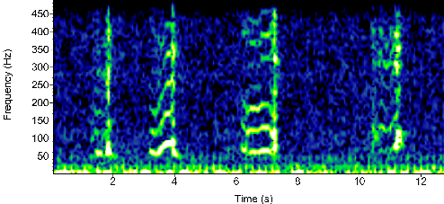

# Fish/Inverts

### Atlantic cod

Scientific name: Gadus Morhua  
Code: ATCO

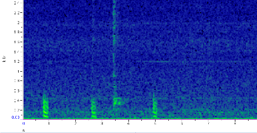

### Haddock

Scientific name: *Melanogrammus aeglefinus*  
Code: HADD

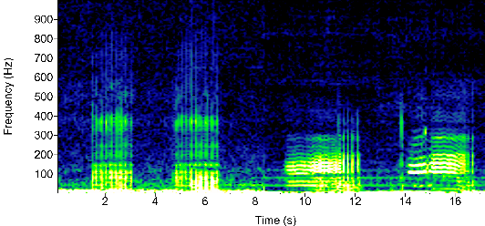

### Snapping Shrimp

Scientific name: *Alpheus sp.*  
Code: SNSH

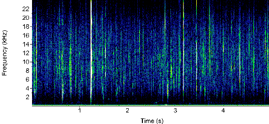

### Unidentified Fish

Code: UNFI

# Environmental

### Earthquakes

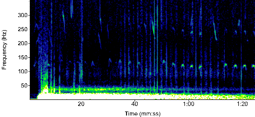

### Rain

Code: RAIN

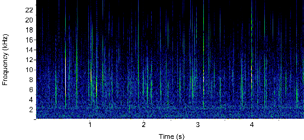

### Thunderstorm

Code: THLI

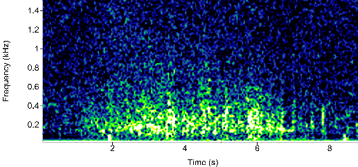

### Unidentified environment

Code: UNEN

# Anthropogenic

### Echosounder

Code: ECHO

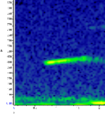

### Pile driver

Code: PIDR

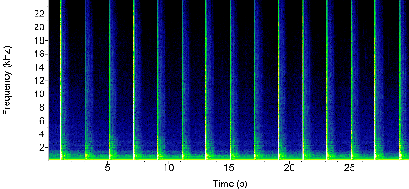

### Seismic surveys

Code: OI-S

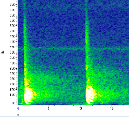

### Unidentified boat/vessel

Code: UNVE

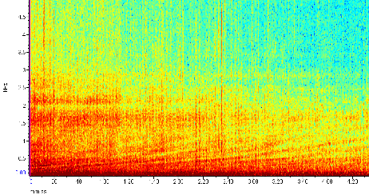

## Sources

Pace, D. S., Lanfredi, C., Airoldi, S., Giacomini, G., Silvestri, M., Pavan, G., & Ardizzone, D. (2021). Trumpet sounds emitted by male sperm whales in the Mediterranean Sea. *Scientific Reports, 11*(1), 1-16.

Cholewiak, D., DeAngelis, A. I., Palka, D., Corkeron, P. J., & Van Parijs, S. M. (2017). Beaked whales demonstrate a marked acoustic response to the use of shipboard echosounders. *Royal Society open science, 4*(12), 170940.

Malinka, C. E., Tønnesen, P., Dunn, C. A., Claridge, D. E., Gridley, T., Elwen, S. H., & Teglberg Madsen, P. (2021). Echolocation click parameters and biosonar behaviour of the dwarf sperm whale (Kogia sima). *Journal of Experimental Biology, 224*(6), jeb240689.

Madsen, P., Wahlberg, M., & Møhl, B. (2002). Male sperm whale (Physeter macrocephalus) acoustics in a high-latitude habitat: implications for echolocation and communication. *Behavioral Ecology and Sociobiology, 53*, 31-41.

Nemiroff, L. (2009). Structural Variation and Communicative Functions of Long-finned Pilot Whale (Globicephala Melas) Pulsed Calls and Complex Whistles.

DeAngelis AI, Stanistreet JE, Baumann-Pickering S, Cholewiak DM (2018). A description of echolocation clicks recorded in the presence of True’s beaked whale (*Mesoplodon mirus*). *J Acoust Soc Am*. *144*(5), 2691